# ANOVA 1

Feb 24 2025

## Topics for this lecture

- Introductory example
- “ANOVA”
- The F-test
- Estimation and parametrization
- Post hoc contrasts and pairwise tests

## Objectives of lecture

- *Basic framework*: The response variable is continuous as for regression but the predictor variables are *factors* like fertilizer, soil type, country, …
- *Basic idea*: The statistical analysis is based on studying the variability in data. Hence the name ANOVA:
  - ANalysis Of VAriance.
- Objectives as for regression: predict and explain

## Example Yields

Yield from a crop experiment on \(k=3\) different soil types. There are \(n_i=10\) random replicates per soil type. A total of \(n=k\cdot n_i = 30\) observations altogether.

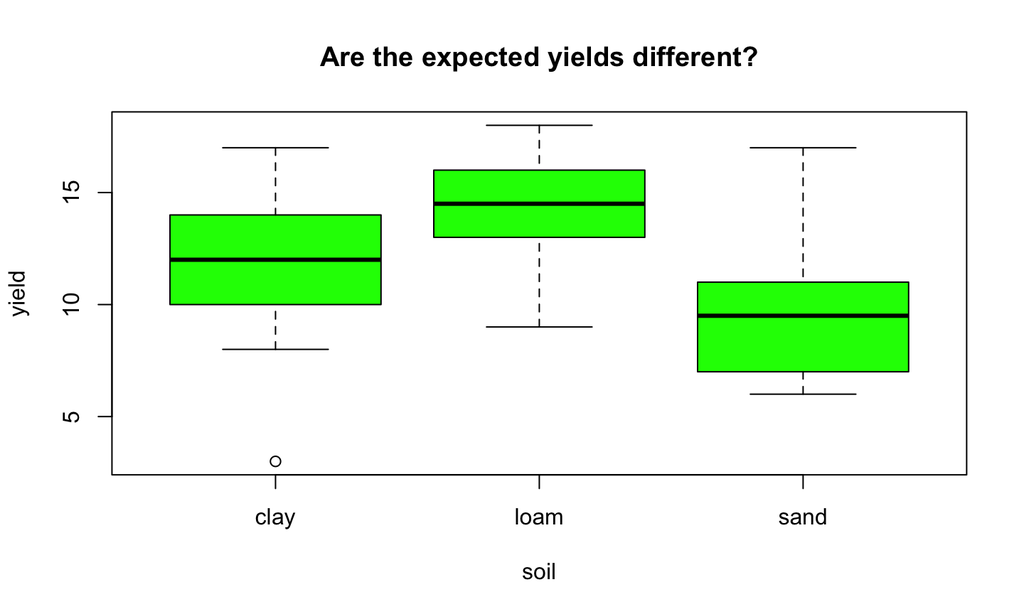

## Linear Regression Formulation

Model with dummy variables for soil type:

\[y_j = \beta_0 + \beta_1 x_{1j} + \beta_2 x_{2j} + \beta_3 x_{3j} + \epsilon_j,\epsilon_j \sim N(0, \sigma^2) \]

where:

- \(x_{1j} = 1\) if soil is clay, else 0
- \(x_{2j} = 1\) if soil is loam, else 0
- \(x_{3j} = 1\) if soil is sand, else 0
- \(\beta_0 = \mu\) = intercept (grand mean)
- \(\beta_0 + \beta_1 = \mu_1\) = mean of yield for clay
- \(\beta_0 + \beta_2= \mu_2\) = mean of yield for loam
- \(\beta_0 + \beta_3 = \mu_3\) = mean of yield for sand

## Linear Regression Reformulate

Model with dummy variables for soil type:

\[y_j = \beta_0 + \beta_2 x_{2j} + \beta_3 x_{3j} + \epsilon_j,\epsilon_j \sim N(0, \sigma^2) \]

where:

- \(x_{2j} = 1\) if soil is loam, else 0
- \(x_{3j} = 1\) if soil is sand, else 0 and hence \(x_{1j} = 1 - x_{2j} - x_{3j}\)
- \(\beta_0 = \mu_1\) = intercept (mean of yield for clay)
- \(\beta_0 + \beta_2= \mu_2\) = mean of yield for loam
- \(\beta_0 + \beta_3 = \mu_3\) = mean of yield for sand
- same model but with \(p=2\) not \(p=3\).

## ANOVA

Let us use two indices instead of dummy variables

- \(i\) - indexes the group (soil type): \(i \in \{1, 2, 3\}\)
- \(j\) - indexes observation within group: \(j \in \{1, \ldots, n_i\}\)

Let \(y_{ij}\) be the observed yield for observation number \(j \in \{1,\ldots, n_i\}\) soil type \(i \in \{1,\ldots, k\}\).

The model (One-way ANOVA): \[y_{ij} = \mu_{i} + \epsilon_{ij}\]

where \(\epsilon_{ij} \sim N(0, \sigma^2)\) and \(\mu_i\) is the expected yield for soil type \(i\).

## Splitting up total variability

SST= \(\sum_{i=1}^{k}\sum_{j=1}^{n_i}(y_{ij}-\bar{y}_{..})^2, \quad \bar{y}_{..}\text{ is grand mean}\)

For the yield data:

```
## [1] 414.7
```

SSA = \(\sum_{i=1}^{k}\sum_{j=1}^{n_i}(\bar{y}_{i.}-\bar{y}_{..})^2 = n\sum_{i=1}^{k}(\bar{y}_{i.}-\bar{y}_{..})^2, \quad \bar{y}_{i.}\text{i-th group mean}\)

For the yield data:

```
## [1] 99.2
```

- SSE = SST - SSA = \(\sum_{i=1}^{k}\sum_{j=1}^{n_i}(y_{ij}-\bar{y}_{i.})^2\) = 414.7 - 99.2 = 315.5

## Between and within group variances:

Dividing Sums of Squares by their respective degrees of freedom gives:

- The between soil type (group) variance: \(MSA = SSA/(k-1) = 99.2/2 = 49.6\)
- The within soil type (group) variance: \(MSE = SSE/(n-k) = 315.5/27 = 11.685\)

where \(n = n_1 + n_2 + \cdots n_k\) is the total number of observations.

**Why does it make sense to compare these?**

## Testing the effect of soil

If there is a soil effect on yield, the expected yields will differ in one way or the other.

Hypotheses:

\[H_0: \mu_1 = \mu_2 =\mu_3 \] vs \[H_1: \mu_i \neq \mu_{i'}\] for at least two different soil types \(i\) and \(i'\).

Reject \(H_0\) if \(MSA >> MSE\)

## Test observator, F

If \(H_0\) is true, then

\[F = \frac{MSA}{MSE} \sim F(\nu_1 = k-1 = 3 -1, \nu_2 = n - k = 30 - 3)\]

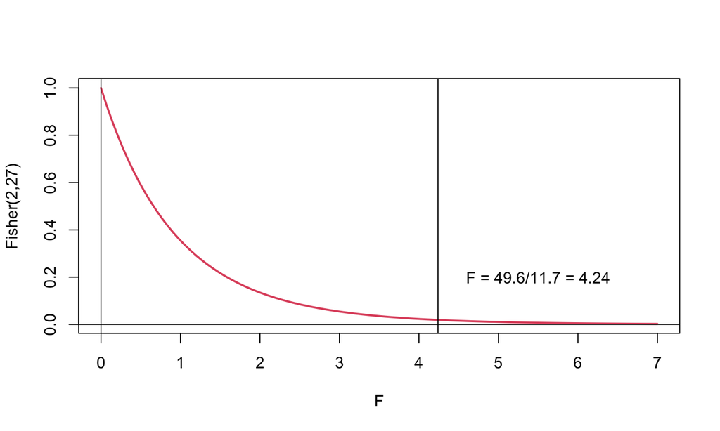

## Rejection region

Reject \(H_0\) at test level \(\alpha\) if \(F_{obs}> F_{\alpha, \nu_1, \nu_2}\), where \(\nu_1 = k-1\) are the degrees of freedom for MSA and \(\nu_2 = n -k\) are the degrees of freedom for MSE.

For example, assume a test level of 5%

From a Fisher table we find \(F_{0.05, 2, 27}\) = 3.35

Alternatively, reject if p-value is smaller than \(\alpha\).

**Conclusion?**

## Estimation of group effects and error variance

The inutitive estimators for \(\mu_i\) are \(\widehat{\mu}_i = \bar{y}_{i.}\)

These are also the least squares estimators (for balanced data), which are unbiased and have minimum variance among all unbiased estimators.

As in regression analysis we have \(\widehat{\sigma}^2 = MSE\).

## Splitting up \(\mu_i\) - i.e. reparametrise

The means may be split up further. Assume

\[\mu_i = \mu + \alpha_i\]

But, all parameters can not be estimated without some extra restriction (choice of parametrization).

- Parametrization 1: Assume \(\sum_{i=1}^k \alpha_i = 0\)

A “sum to zero” parametrization (“contr.sum” in R”)

- Parametrization 2: Assume \(\alpha_1 = 0\)

A “reference level” or “control level” parametrization (“contr.treatment” in R”)

## Choice of arametrization in RStudio

Parametrization 1 (Using the lm-function in the mixlm-package)

```r
mod1 <- lm(yield~soil, data=yields, contrasts = "contr.sum")
```

Parametrization 2 (Using the lm-function in the mixlm-package

```r
mod1 <- lm(yield~soil, data=yields, contrasts = "contr.treatment")
```

## Example: Parametrization 1

```
##             Estimate Std. Error t value Pr(>|t|)
## (Intercept)     11.9     0.6241 19.0673   0.0000
## soil(clay)      -0.4     0.8826 -0.4532   0.6540
## soil(loam)       2.4     0.8826  2.7192   0.0113
```

Compare with group and total means:

```r
means <- c(soilmeans,mean(soilmeans))
names(means) <- c("clay", "loam", "sand", "total-mean")
print(means)
```

```
##       clay       loam       sand total-mean
##       11.5       14.3        9.9       11.9
```

## Example: Parametrization 2

```
##             Estimate Std. Error t value Pr(>|t|)
## (Intercept)     11.5     1.0810 10.6385   0.0000
## soil(loam)       2.8     1.5287  1.8316   0.0781
## soil(sand)      -1.6     1.5287 -1.0466   0.3046
```

Compare with group and total means:

```
##       clay       loam       sand total-mean
##       11.5       14.3        9.9       11.9
```

## ANOVA table of Sum of squares

This table does not depend on parametrization

```
## Analysis of Variance Table
##
## Response: yield
##           Df Sum Sq Mean Sq F value  Pr(>F)
## soil       2   99.2  49.600  4.2447 0.02495 *
## Residuals 27  315.5  11.685
## ---
## Signif. codes:  0 '***' 0.001 '**' 0.01 '*' 0.05 '.' 0.1 ' ' 1
```

## Residual analysis

We should also for ANOVA-models check the assumptions by residual analysis

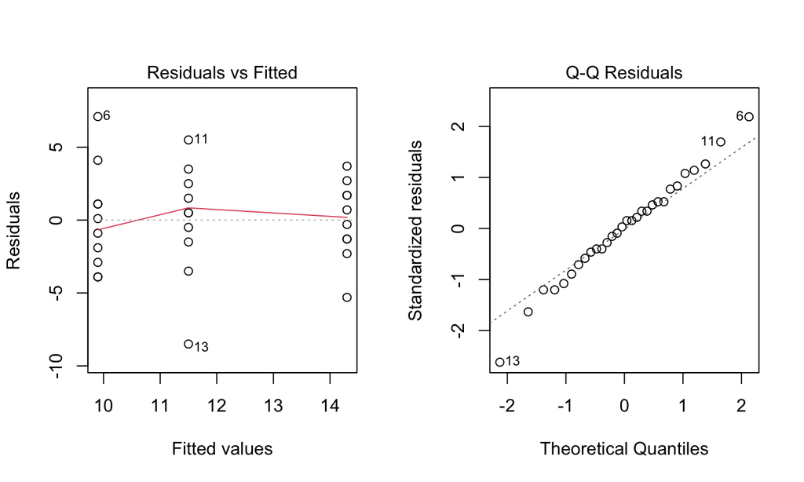

## Pair-wise contrasts

If a factor is significant and has more than two levels: Where are the differences?

May perform a “post hoc” test with contrasts.

A contrasts is a linear function of the factor effects.

\[\theta = c_1 \mu_1 + c_2 \mu_2 + c_3 \mu_3\]

where \(\sum_{i=1}^k c_i= 0\)

For pair-wise contrasts, only two \(c_i\)’s differ from 0.

## Example 1 (With parametrization 1)

\(\theta_1 = 1\mu_1 + (-1)\mu_2 + 0 \mu_3\)

\(= 1(\mu + \alpha_1) - 1(\mu + \alpha_2) = \alpha_1 -\alpha_2\)

Estimate: \(\widehat{\theta}_1 = \widehat{\alpha}_1 -\widehat{\alpha}_2 = -0.4 - 2.4 = -2.8\)

```r
gmodels::fit.contrast(model=mod1, varname='soil', df=TRUE, coeff=c(1, -1, 0), conf.int=0.95)
```

```
##                   Estimate Std. Error   t value   Pr(>|t|) DF  lower CI
## soil c=( 1 -1 0 )     -2.8   1.528737 -1.831577 0.07806971 27 -5.936709
##                    upper CI
## soil c=( 1 -1 0 ) 0.3367094
```

## Example 2: “loam” vs “sand”

Define required pairwise contrast:

\(\theta_2 = 0\mu_1 + 1\mu_2 - 1\mu_3\) \(= 1(\mu + \alpha_2) - 1(\mu + \alpha_3) = \alpha_2 - \alpha_3\)

Estimation

\(\widehat{\alpha}_3 = -(-0.4 + 2.4) = -2\) \(\widehat{\theta}_2 = \widehat{\alpha}_2 - \widehat{\alpha}_3 = 2.4 - (-2) = 4.4\)

```
##                   Estimate Std. Error  t value    Pr(>|t|) DF lower CI upper CI
## soil c=( 0 1 -1 )      4.4   1.528737 2.878193 0.007728022 27 1.263291 7.536709
```

## Multiple testing - Tukey test

Type 1: \(\alpha\) = P(Rejecting \(H_0\) | \(H_0\) is TRUE)

If there are many levels of a factor, a Tukey test is preferable.

Controls overall error rate (family-wise error) of all pairwise tests.

Use ‘simple.glht’-function in the mixlm-package.

```r
ptests <- mixlm::simple.glht(mod1, "soil", corr = c("Tukey"),level = 0.95)
print(ptests)
plot(ptests)
```

## R Commander output - Tukey

```
##
##   Simultaneous Confidence Intervals and Tests for General Linear Hypotheses
##
## Multiple Comparisons of Means: Tukey Contrasts
##
##
## Fit: stats::lm(formula = yield ~ soil, data = yields)
##
## Quantile = 2.4794
## Minimum significant difference = 3.7904
## 95% confidence level
##
## Linear Hypotheses:
##             Lower  Center   Upper Std.Err t value  P(>t)
## clay-loam -6.5904 -2.8000  0.9904  1.5287  -1.832 0.1785
## clay-sand -2.1904  1.6000  5.3904  1.5287   1.047 0.5546
## loam-sand  0.6096  4.4000  8.1904  1.5287   2.878 0.0204 *
## ---
## Signif. codes:  0 '***' 0.001 '**' 0.01 '*' 0.05 '.' 0.1 ' ' 1
## (Adjusted p values reported -- single-step method)
```

## Pairwise confidence intervals plot

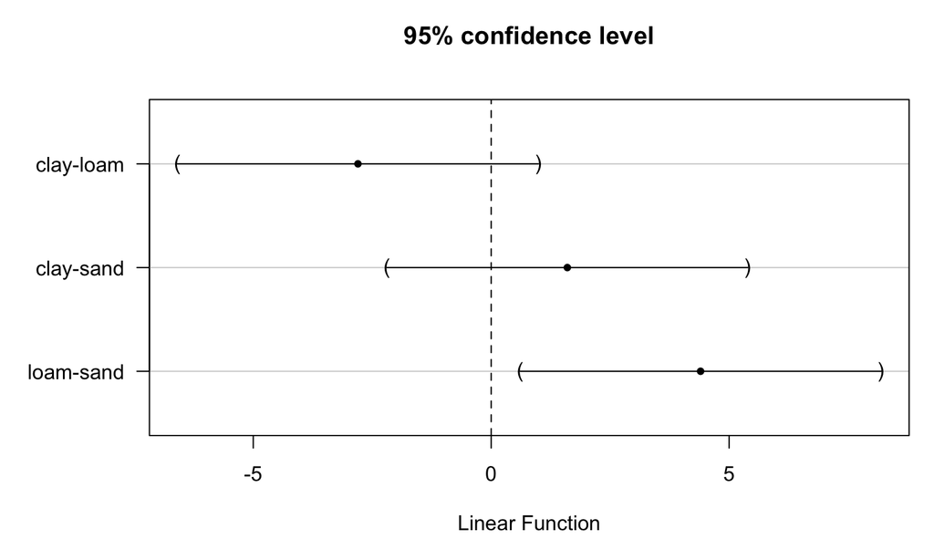

## The ANOVA applet

The ANOVA “idea”: Studying means by splitting variability

[ANOVA shiny app](https://solve.shinyapps.io/ANOVA/)

## Topics for next lecture

- ANOVA with several factors
- The factorial applet
- Effect plots
- Estimation and hypothesis testing
- Tukey test and confidence intervals
- ANCOVA

## Announcements

- Elias is travelling, online session this Thursday https://nmbu.zoom.us/j/66481255218?pwd=qgcDFZ3T7MxuLVAARpw8ukot98Qhv0.1 Meeting ID: 664 8125 5218 Passcode: 406893

-[What do we do with mondays](https://www.mentimeter.com/app/presentation/alvmjssjcyvd8zdzrwxw3tqapgghqi35/)

- Assignment 1 will be published as a quiz next Tuesday, deadline March 10. 70% needed to pass.
- Practice quiz on canvas!